# R Workshop – Day 2

### Hands On

Work on airway data:

```r
airway.D = read.delim2('data/airway_gene_expression.tsv', as.is = T, header = T)
airway.I = read.delim2('data/airway_sample_info.tsv', as.is = T, header = T)
# make Gene ID to row names
head(airway.ge, n = 5)
##            GeneID S_01.control.Rep1 S_02.__treat.Rep1 S_03.control.Rep2
## 1 ENSG00000000003               679               448               873
## 2 ENSG00000000005                 0                 0                 0
## 3 ENSG00000000419               467               515               621
## 4 ENSG00000000457               260               211               263
## 5 ENSG00000000460                60                55                40
##   S_04.__treat.Rep2 S_05.control.Rep3 S_06.__treat.Rep3 S_07.control.Rep4
## 1               408              1138              1047               770
## 2                 0                 0                 0                 0
## 3               365               587               799               417
## 4               164               245               331               233
## 5                35                78                63                76
##   S_08.__treat.Rep4
## 1               572
## 2                 0
## 3               508
## 4               229
## 5                60
```

```r
# subset to rows with mean > 5
airway.D = subset(airway.D, rowMeans(airway.D[, 2:9]) > 5)

# claculate averages for before and after intervention
mean.before = rowMeans(airway.D[airway.I[airway.I$Intervention == "before",]$SampleName])
mean.after = rowMeans(airway.D[airway.I[airway.I$Intervention == "after",]$SampleName])
```

- Draw a histogram of the `log2(mean)` before the intervention (average over all replicates)
  - `hist(... , breaks = 100)`
- Add the histogram of log2(mean) after the intervention (average over all replicates)
  - using the same breaks `H1 = hist(...)` and `H2 = hist(..., breaks = H1$breaks, add = TRUE )`

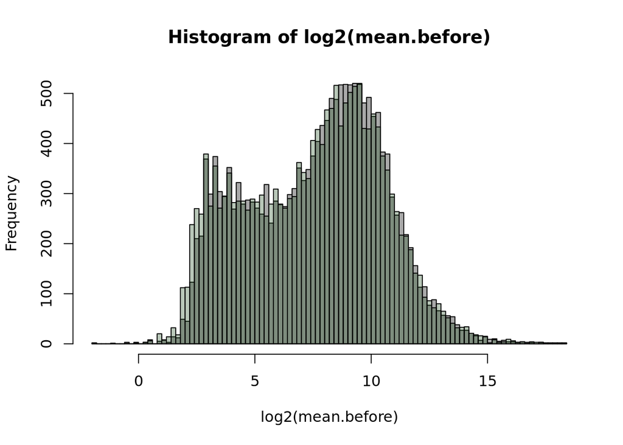

## Heatmap

Heatmaps are another regular plot to describe expression data among many other applications.  
We will use the data and code from this webpage: https://davetang.org/muse/2018/05/15/making-a-heatmap-in-r-with-the-pheatmap-package/

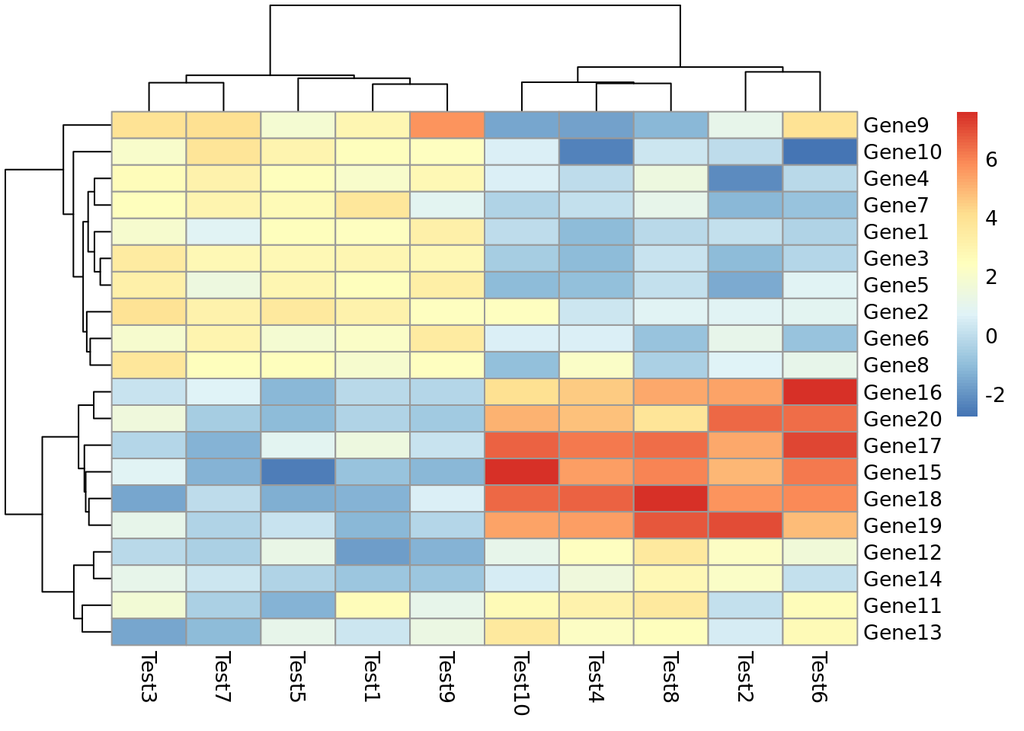

```r
library(pheatmap)

# Generate some data
test = matrix(rnorm(200), 20, 10)
test[1:10, seq(1, 10, 2)] = test[1:10, seq(1, 10, 2)] + 3
test[11:20, seq(2, 10, 2)] = test[11:20, seq(2, 10, 2)] + 2
test[15:20, seq(2, 10, 2)] = test[15:20, seq(2, 10, 2)] + 4
colnames(test) = paste("Test", 1:10, sep = "")
rownames(test) = paste("Gene", 1:20, sep = "")

# Draw heatmaps
pheatmap(test)
```

### Hands On

- Draw a heatmap from the first 300 lines of test data set
  - `pheatmpa(as.matrix(airway.D[<correct row indeces>, <only numerical columns>]))`

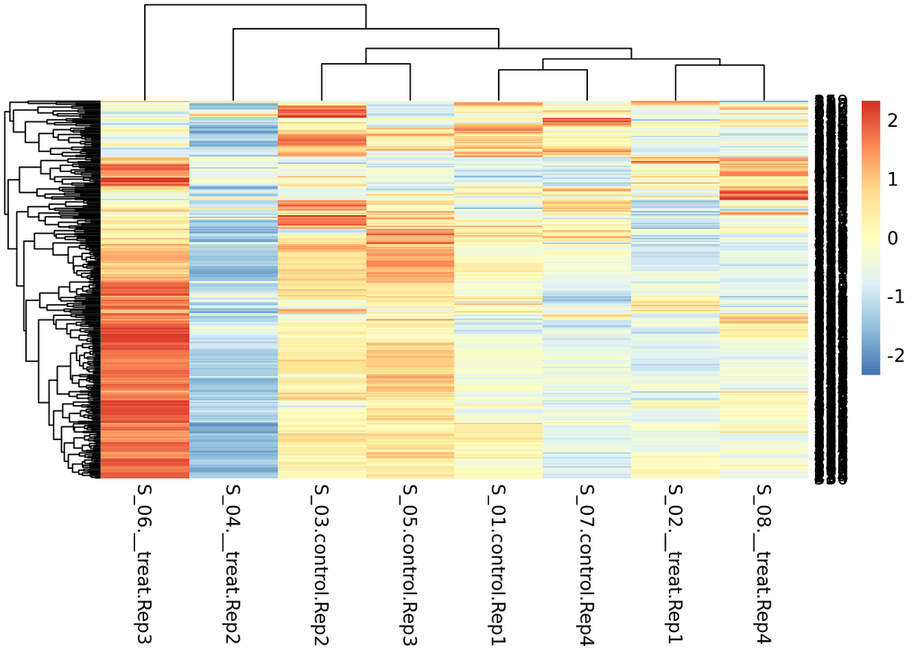

- Draw a heatmap of only the significantly (p <= 0.01) changed rows

```r
airway.D = read.delim2('data/airway_gene_expression.tsv', as.is = T, header = T)
airway.D = subset(airway.D, rowMeans(airway.D[, 2:9]) > 5)

  for(i in 1:nrow(airway.D)){
    # calculate p.value
    airway.D[i,'p.value'] = as.numeric(t.test(airway.D[i,c(2, 4, 6, 8)], airway.D[i,c(3,5,7,9)])$p.value)
}

head(airway.D)
##            GeneID S_01.control.Rep1 S_02.__treat.Rep1 S_03.control.Rep2
## 1 ENSG00000000003               679               448               873
## 3 ENSG00000000419               467               515               621
## 4 ENSG00000000457               260               211               263
## 5 ENSG00000000460                60                55                40
## 7 ENSG00000000971              3251              3679              6177
## 8 ENSG00000001036              1433              1062              1733
##   S_04.__treat.Rep2 S_05.control.Rep3 S_06.__treat.Rep3 S_07.control.Rep4
## 1               408              1138              1047               770
## 3               365               587               799               417
## 4               164               245               331               233
## 5                35                78                63                76
## 7              4252              6721             11027              5176
## 8               881              1424              1439              1359
##   S_08.__treat.Rep4    p.value
## 1               572 0.22082663
## 3               508 0.82755428
## 4               229 0.67474685
## 5                60 0.38412456
## 7              7995 0.49498597
## 8              1109 0.04771523
```

- use `subset(data, condition)` to subset to only significant genes

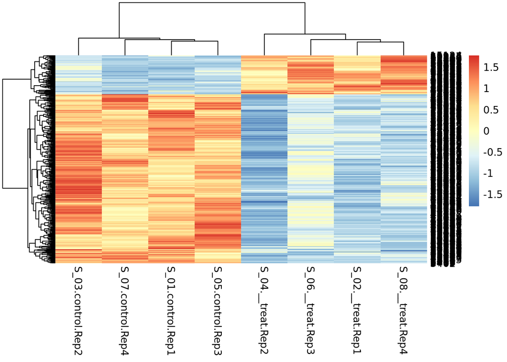

## Barplot

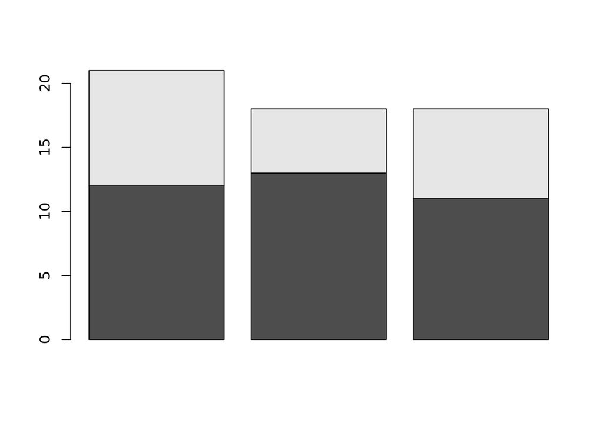

```r
M = matrix(c(12, 13, 11, 9, 5, 7 ), byrow = T, ncol = 3)
barplot(M)
```

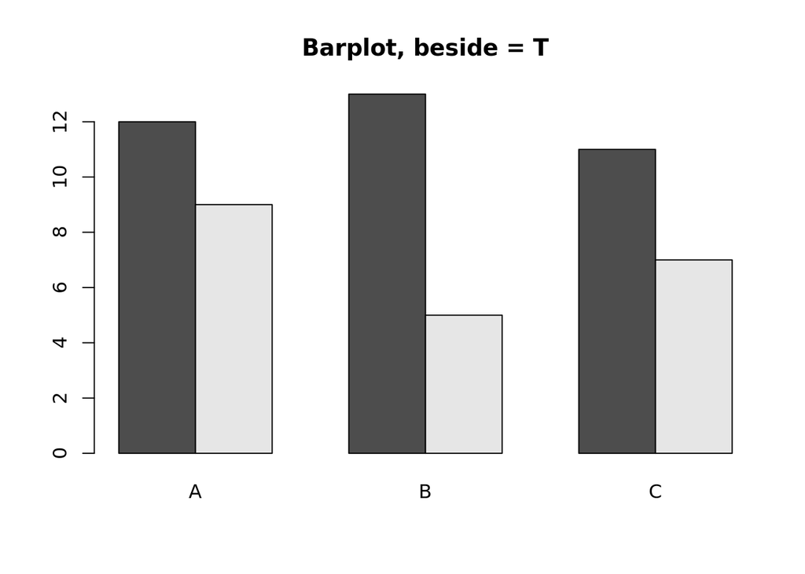

```r
barplot(M, beside = T, main = 'Barplot, beside = T', names.arg = c('A', 'B', 'C'))
```

### Hands On

- Draw a barplot with the average expression level per replicate
  - use `colMeans(airway.D[, 2:9])`

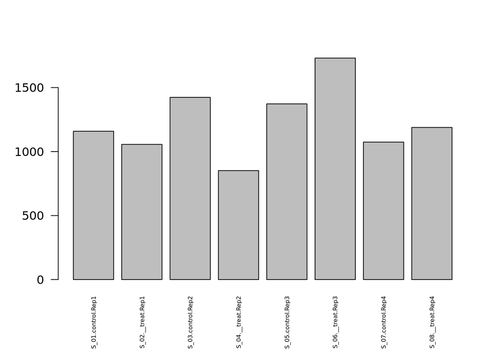

## Boxplot

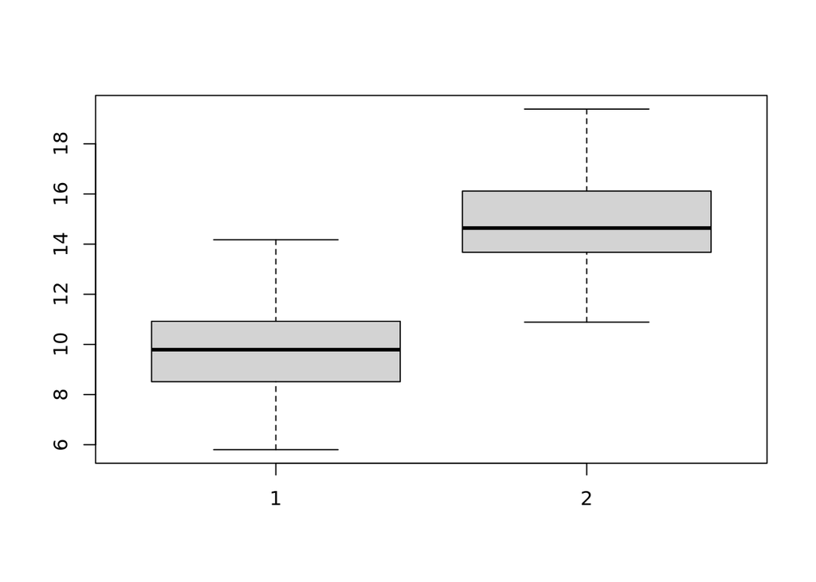

```r
x = rnorm(100, 10, 2)
y = rnorm(100, 15, 2)

boxplot(list(x, y))
```

You can also plot multiple boxes by using a group variable

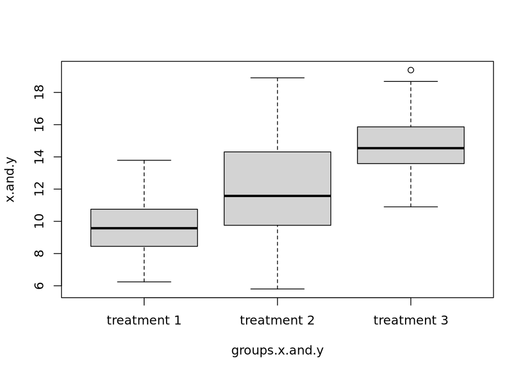

```r
x.and.y = c(x, y)
groups.x.and.y = c(rep('treatment 1', 50), rep('treatment 2', 80), rep( 'treatment 3', 70))

boxplot(x.and.y ~ groups.x.and.y)
```

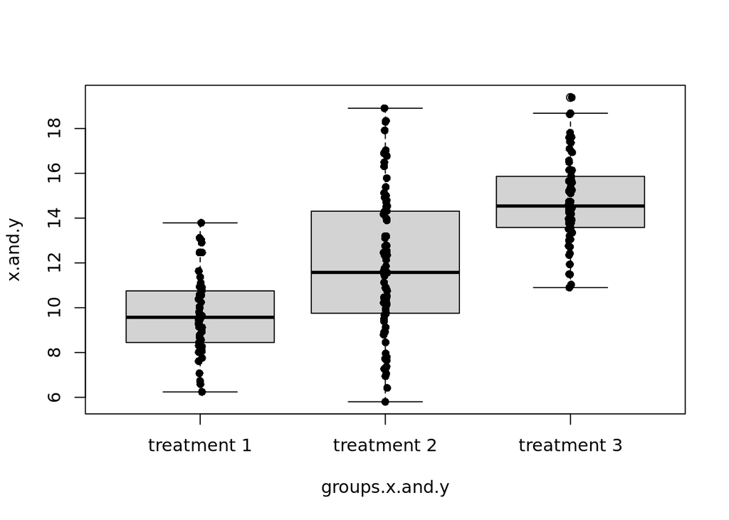

```r
boxplot(x.and.y ~ groups.x.and.y)
stripchart(x.and.y ~ groups.x.and.y, vertical = TRUE, method = "jitter", jitter=0.01, pch = 16, add = TRUE)
```

### Hands On

- Draw a boxplot using the test data table, one box per replicate
  - log2 of the expression values for better visualization
  - `log2(airway.D[, <correct columns>])`
  - `boxplot()`

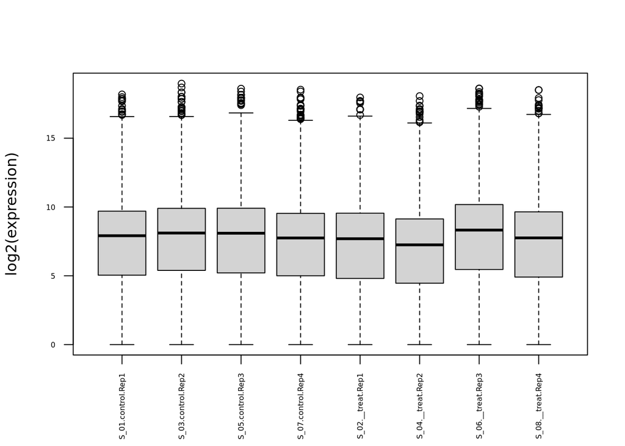

- using [ggplot2](https://ggplot2.tidyverse.org/) to make the box plot

```r
install.packages("ggplot2")
install.packages("reshape2")
```

```r
library(ggplot2)
library(reshape2)

log2_airway.D <- log2(airway.D[,c(2, 4, 6, 8, 3, 5, 7, 9)])
melted_data <- melt(as.data.frame(log2_airway.D))
## No id variables; using all as measure variables
```

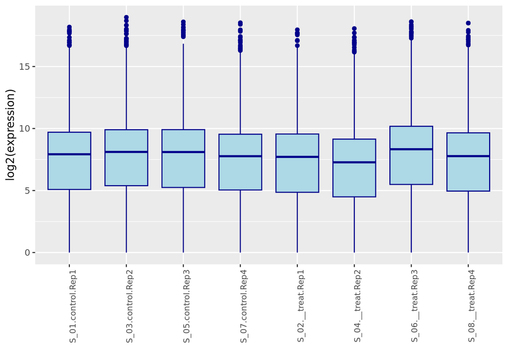

```r
ggplot(melted_data, aes(x = variable, y = value)) +
  geom_boxplot(fill = "lightblue", color = "darkblue") +
  theme(axis.text.x = element_text(angle = 90, hjust = 1, size = 8)) +
  labs(x = "", y = "log2(expression)")
```

### Advanced links (plotting)

- data to viz: https://www.data-to-viz.com/
- R plot gallery: https://www.r-graph-gallery.com/

# End of the day challenge

Pick a plot from the R graph gallery and reproduce the plot. I also encourage you to explore the data. In some cases you will need to install extra libraries, but don’t be afraid, R-studio usually helps you with that. If we have time I would like you to share your plot and quickly explain what you visualized.

# Recommended further reading

- Introduction to the tidyverse: https://r4ds.had.co.nz/introduction.html

# And for tomorrow:

Tomorrow we will perform a real differential gene expression analysis, following the DESeq2 Tutorial https://www.bioconductor.org/packages/release/bioc/vignettes/DESeq2/inst/doc/DESeq2.html

To ensure that everything is running smoothly, please make sure that you have the following libraries installed. If not please install them using either `install.packages()` or Bioconductor.

```r
# loading all libraries

# cran libraries
install.packages("magrittr")
install.packages("dplyr")
install.packages("ggplot2")
install.packages("pheatmap")
install.packages("RColorBrewer")
install.packages("PoiClaClu")
install.packages("ggbeeswarm")
install.packages("dbplyr")

library("magrittr")
library("dplyr")
library("ggplot2")
library("pheatmap")
library("RColorBrewer")
library("PoiClaClu")
library("ggbeeswarm")


# bioconductor libraries
if (!requireNamespace("BiocManager", quietly = TRUE))
    install.packages("BiocManager", repos='http://cran.us.r-project.org' , dependencies = TRUE)

BiocManager::install("airway")
BiocManager::install("GenomicFeatures")
BiocManager::install("GenomicAlignments")
BiocManager::install("Rsamtools")
BiocManager::install("BiocParallel")
BiocManager::install("DESeq2")
BiocManager::install("vsn")
BiocManager::install("apeglm")
BiocManager::install("genefilter")
BiocManager::install("AnnotationDbi")
BiocManager::install("org.Hs.eg.db")
BiocManager::install("ReportingTools")
BiocManager::install("Gviz")
BiocManager::install("sva")
BiocManager::install("RUVSeq")
BiocManager::install("fission")
BiocManager::install("tximeta")

library("airway")
library("GenomicFeatures")
library("GenomicAlignments")
library("Rsamtools")
library("BiocParallel")
library("DESeq2")
library("vsn")
library("apeglm")
library("genefilter")
library("AnnotationDbi")
library("org.Hs.eg.db")
library("ReportingTools")
library("Gviz")
library("sva")
library("RUVSeq")
library("fission")
library("tximeta")
```